# Introduction to Matplotlib

## Overview

matplotlib is a python library that is useful for making static visualizations, including scientific visualizations.

Rather than using a Grammar of Graphics approach (which we will utilize with Altair), matplotlib can be used to make specific types of visualizations (scatterplots, barplots, etc.).

It offers many options and can be highly customized, although it can sometimes be difficult to figure out how to do something specific. The documentation and sites like stackoverflow are helpful here.

Additional tutorials are available here: https://matplotlib.org/stable/tutorials/index, https://jakevdp.github.io/PythonDataScienceHandbook/04.00-introduction-to-matplotlib.html

## Environment setup

```python
# Uncomment the below lines if you need to install these packages.
# %pip install matplotlib
# %pip install pandas
# %pip install nbconvert
# %pip install numpy
```

```python
import matplotlib.pyplot as plt
import numpy as np
import pandas as pd

from collections import Counter
```

## A simple example

Let's first create a simple dataset and make a figure! Here are the basic components of a matplotlib visualization:

**Figure:** The entire plot or canvas for the visualization.

**Axes:** The area/pane within a figure where you plot the data. You can have multiple axes in one figure.

**Line & Marks:** Data representations

**Axis:** X & Y, with limits and ticks representing data

**Labels:** Labels for X & Y axes, labels for data points

**Title:** Text at the top of the plot

```
Figure type:  <class 'matplotlib.figure.Figure'>
Ax type:  <class 'matplotlib.axes._axes.Axes'>
```

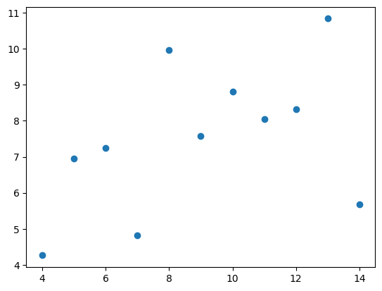

```python
# Create some data
x = [4.0, 5.0, 6.0, 7.0, 8.0, 9.0, 10.0, 11.0, 12.0, 13.0, 14.0]
y = [4.26, 6.95, 7.24, 4.82, 9.96, 7.58, 8.81, 8.04, 8.33, 10.84, 5.68,]

# Create a plot
fig, ax = plt.subplots()

print('Figure type: ',type(fig))
print('Ax type: ',type(ax))

# Plot the data on the axis as a scatter plot
ax.scatter(x, y)

# Show the plot -- What happens if you comment this out?
plt.show()
```

### Exercise 1: Make a line chart of the same data as above.

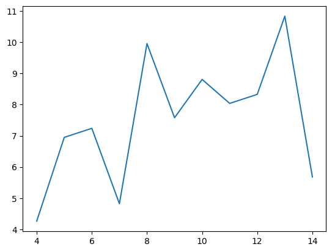

```python
# insert code here
fig,ax = plt.subplots()
ax.plot(x,y)
plt.show()
```

## Creating plots with multiple axes

```
Axes type:  <class 'numpy.ndarray'>
Individual ax type:  <class 'matplotlib.axes._axes.Axes'>
```

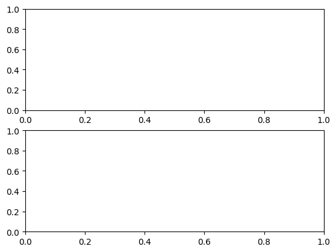

```python
# Create a plot with multiple panes (2 rows)
fig, axes = plt.subplots(nrows=2)

print('Axes type: ',type(axes))
print('Individual ax type: ',type(axes[0]))

plt.show()
```

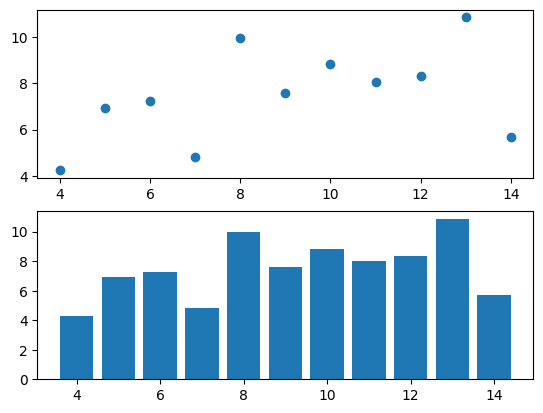

```python
fig, axes = plt.subplots(nrows=2)

# plot the data on the first axis
ax = axes[0]
ax.scatter(x, y)

# plot it as a bar plot on the second axis
ax = axes[1]
ax.bar(x, y)

plt.show()
```

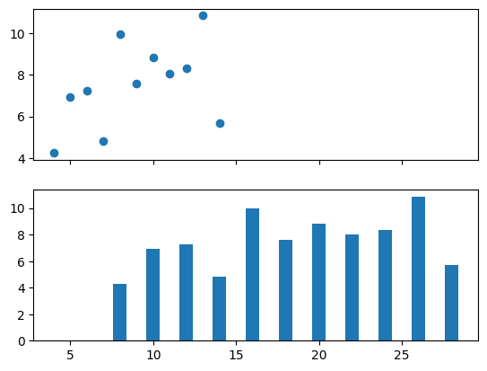

```python
# Link the panes together (use the same x-axis)
fig, axes = plt.subplots(nrows=2, sharex=True)

# plot the data on the first axis
ax = axes[0]
ax.scatter(x, y)

# plot it as a bar plot on the second axis
ax = axes[1]
ax.bar([val * 2 for val in x], y)

plt.show()
```

### Exercise 2: Recreate the above plot with two columns instead of two rows.

Have them share the same y-axis.

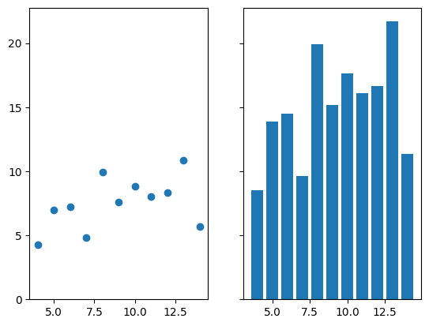

```python
# insert code here
# Link the panes together (use the same x-axis)
fig, axes = plt.subplots(ncols=2, sharey=True)

# plot the data on the first axis
ax = axes[0]
ax.scatter(x, y)

# plot it as a bar plot on the second axis
ax = axes[1]
ax.bar(x, [val * 2 for val in y])

plt.show()
```

## What's missing?

**Plot aesthetics!** (figure size, symbols, labels, tickmarks, and legends)

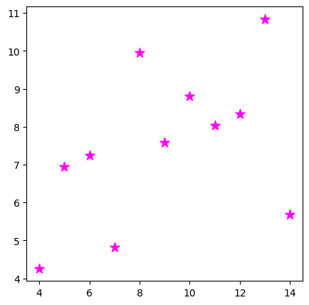

```python
# Create a square figure
fig, ax = plt.subplots(figsize=(5, 5))

# Change the size and color of the scatter plot
ax.scatter(x, y, s=100, color='magenta', marker='*')

# For more colors, see: https://matplotlib.org/stable/gallery/color/named_colors.html
# you can also use hex codes like color="#058ED9" or RGB values color=[0.8, 0.5, 0.1]

# For marker styles, see: https://matplotlib.org/stable/api/markers_api.html

plt.show()
```

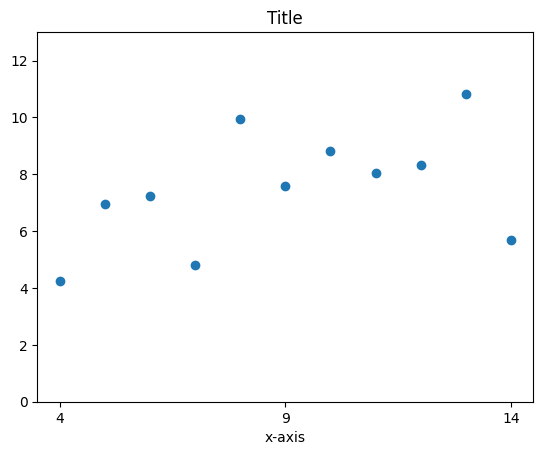

```python
fig, ax = plt.subplots()

ax.scatter(x, y)

# Change the limits of the y-axis
ax.set_ylim(0, 13)

# Change the tick-marks on x-axis
ax.set_xticks([4, 9, 14])

# Add a label on the x-axis
ax.set_xlabel("x-axis")

# Add a title:
ax.set_title("Title")


# Show the plot
plt.show()
```

### Exercise 3: Make a scatter plot using using pink squares and include x & y labels.

Use the hex code "#FF729F" or RBG values [1, .447, .624] to color the marks.

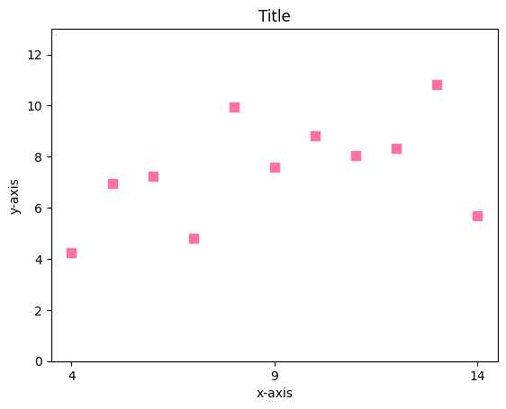

```python
# insert code here
fig, ax = plt.subplots()

ax.scatter(x, y, s=50, color=[1,.447,.624], marker='s')

# Change the limits of the y-axis
ax.set_ylim(0, 13)

# Change the tick-marks on x-axis
ax.set_xticks([4, 9, 14])

# Add a label on the x-axis
ax.set_xlabel("x-axis")

ax.set_ylabel("y-axis")

# Add a title:
ax.set_title("Title")


# Show the plot
plt.show()
```

## Adding text labels to plot

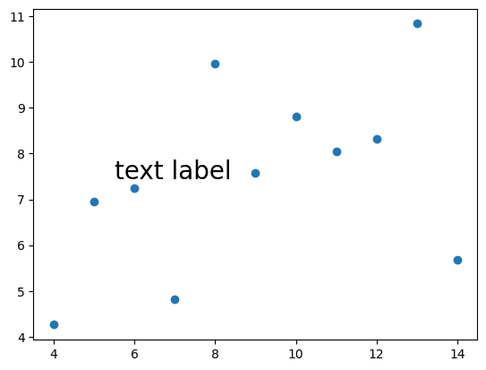

```python
fig, ax = plt.subplots()

ax.scatter(x, y)

# Add a big text label for the second point (note that it is not jittered)
ax.text(x[1]+0.5, y[1]+0.5, 'text label', size=20)

plt.show()
```

## Additional dimensions

Color & size can encode additional information.

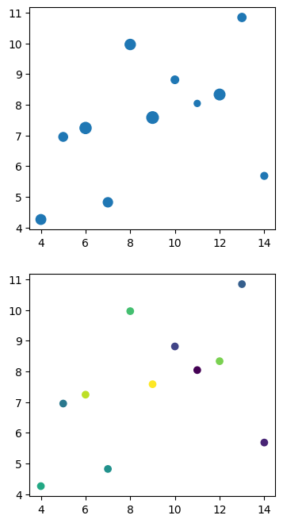

```python
# Add a third dimension of data
z = np.array([10.0, 8.0, 13.0, 9.0, 11.0, 14.0, 6.0, 4.0, 12.0, 7.0, 5.0])

fig, axes = plt.subplots(nrows=2, figsize=(4, 8))

# make a scatter plot, use the z variable to control size
ax = axes[0]
ax.scatter(x, y, s=z*8)

# or use the z variable to control color
ax = axes[1]
ax.scatter(x, y, c=z)

plt.show()
```

### Exercise 4: How can we add a title to each chart?

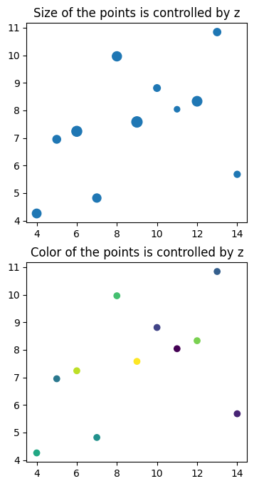

```python
# insert code here
# Add a third dimension of data
z = np.array([10.0, 8.0, 13.0, 9.0, 11.0, 14.0, 6.0, 4.0, 12.0, 7.0, 5.0])

fig, axes = plt.subplots(nrows=2, figsize=(4, 8))

# make a scatter plot, use the z variable to control size
ax = axes[0]
ax.scatter(x, y, s=z*8)
ax.set_title('Size of the points is controlled by z')

# or use the z variable to control color
ax = axes[1]
ax.scatter(x, y, c=z)
ax.set_title('Color of the points is controlled by z')

plt.show()
```

```
Scatter type:  <class 'matplotlib.collections.PathCollection'>
```

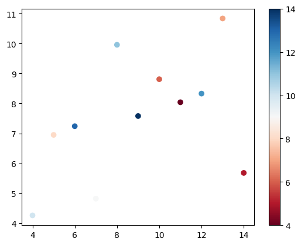

```python
fig, ax = plt.subplots()

# Use a different color mapping, and get the object for this scatter plot
# More information on cmaps: https://matplotlib.org/stable/users/explain/colors/colormaps.html
output = ax.scatter(x, y, c=z, cmap='RdBu')
print('Scatter type: ',type(output))

plt.colorbar(output, ax=ax)

plt.show()
```

# Line plots, legends, and default colors

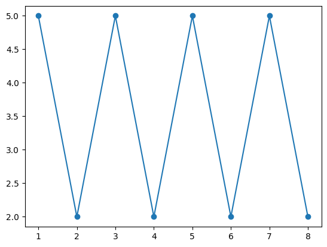

```python
x = [1, 2, 3, 4, 5, 6, 7, 8]
y = [5, 2, 5, 2, 5, 2, 5, 2]
z = [2, 4, 5, 4, 1, 3, 6, 4]

fig, ax = plt.subplots()

# The default plot is a line plot
ax.plot(x, y)
ax.scatter(x, y)

plt.show()
```

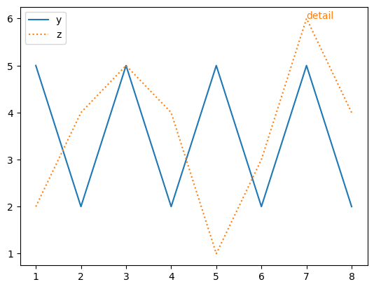

```python
fig, ax = plt.subplots()

# We can name the lines using "label"
ax.plot(x, y, label='y')

# We can also put additional series on the same axis (and use a different line-style)
ax.plot(x, z, label='z', linestyle=':')

# It will automatically change the color, which we can access as C0, C1, C2, ...

# Add a text detail in the second color
ax.text(x[-2], z[-2], 'detail', color='C1')

# The line names will automatically show up in the legend, which we place in a corner
ax.legend(loc='upper left')

plt.show()
```

## Working with data

For this lab, we will be looking at the [Taylor Swift Spotify Dataset](https://www.kaggle.com/datasets/jarredpriester/taylor-swift-spotify-dataset?resource=download) from Kaggle.

```python
# Load the Taylor Swift data
df = pd.read_csv('taylor_swift_spotify.csv', index_col=0)
df.head()
```

|  | name | album | release_date | track_number | id | uri | acousticness | danceability | energy | instrumentalness | liveness | loudness | speechiness | tempo | valence | popularity | duration_ms |
| --- | --- | --- | --- | --- | --- | --- | --- | --- | --- | --- | --- | --- | --- | --- | --- | --- | --- |
| 0 | Fortnight (feat. Post Malone) | THE TORTURED POETS DEPARTMENT: THE ANTHOLOGY | 2024-04-19 | 1 | 6dODwocEuGzHAavXqTbwHv | spotify:track:6dODwocEuGzHAavXqTbwHv | 0.5020 | 0.504 | 0.386 | 0.000015 | 0.0961 | -10.976 | 0.0308 | 192.004 | 0.281 | 82 | 228965 |
| 1 | The Tortured Poets Department | THE TORTURED POETS DEPARTMENT: THE ANTHOLOGY | 2024-04-19 | 2 | 4PdLaGZubp4lghChqp8erB | spotify:track:4PdLaGZubp4lghChqp8erB | 0.0483 | 0.604 | 0.428 | 0.000000 | 0.1260 | -8.441 | 0.0255 | 110.259 | 0.292 | 79 | 293048 |
| 2 | My Boy Only Breaks His Favorite Toys | THE TORTURED POETS DEPARTMENT: THE ANTHOLOGY | 2024-04-19 | 3 | 7uGYWMwRy24dm7RUDDhUlD | spotify:track:7uGYWMwRy24dm7RUDDhUlD | 0.1370 | 0.596 | 0.563 | 0.000000 | 0.3020 | -7.362 | 0.0269 | 97.073 | 0.481 | 80 | 203801 |
| 3 | Down Bad | THE TORTURED POETS DEPARTMENT: THE ANTHOLOGY | 2024-04-19 | 4 | 1kbEbBdEgQdQeLXCJh28pJ | spotify:track:1kbEbBdEgQdQeLXCJh28pJ | 0.5600 | 0.541 | 0.366 | 0.000001 | 0.0946 | -10.412 | 0.0748 | 159.707 | 0.168 | 82 | 261228 |
| 4 | So Long, London | THE TORTURED POETS DEPARTMENT: THE ANTHOLOGY | 2024-04-19 | 5 | 7wAkQFShJ27V8362MqevQr | spotify:track:7wAkQFShJ27V8362MqevQr | 0.7300 | 0.423 | 0.533 | 0.002640 | 0.0816 | -11.388 | 0.3220 | 160.218 | 0.248 | 80 | 262974 |

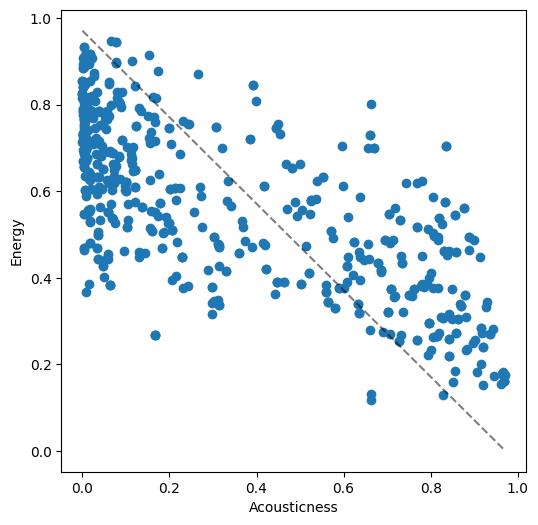

```python
# plot energy by acousticness
x = df['acousticness'].values
y = df['energy'].values

fig, ax = plt.subplots(figsize=(6,6))
ax.scatter(x, y)

ax.set_xlabel('Acousticness')
ax.set_ylabel('Energy')

# add a dashed line for the diagonal
ax.plot([min(x), max(x)], [max(x), min(x)], linestyle='--', color='k', alpha=0.5)

plt.show()
```

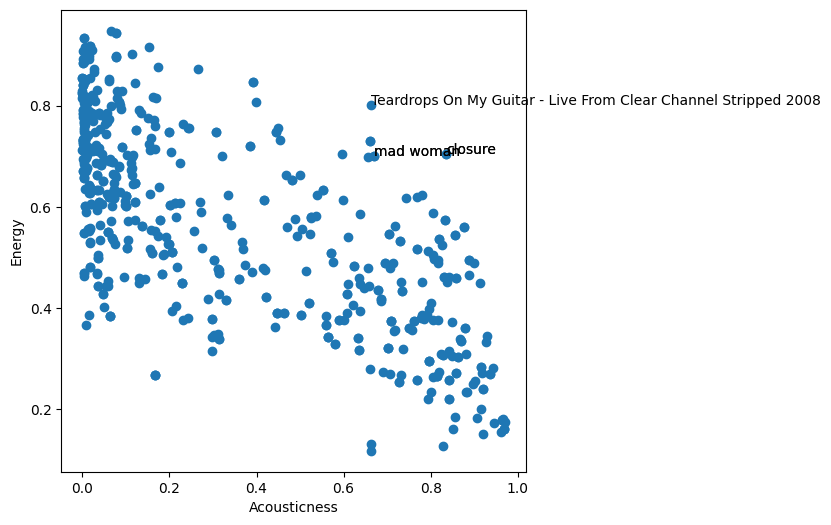

```python
# plot energy by acousticness
x = df['acousticness'].values
y = df['energy'].values

fig, ax = plt.subplots(figsize=(6,6))
ax.scatter(x, y)

ax.set_xlabel('Acousticness')
ax.set_ylabel('Energy')

# add labels for outliers
titles = df['name'].values
for i, yi in enumerate(y):
    if yi > .66 and x[i] > .66:
        ax.text(x[i], y[i], titles[i])

plt.show()
```

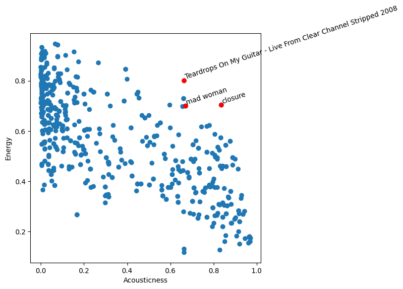

```python
# increase the font size, change text alignment, and adjust the limits to make the text fit in

# plot energy by acousticness
x = df['acousticness'].values
y = df['energy'].values

fig, ax = plt.subplots(figsize=(6,6))
ax.scatter(x, y)

ax.set_xlabel('Acousticness')
ax.set_ylabel('Energy')

# add labels for outliers
titles = df['name'].values
labeled = [] # because his data set has duplicates, we want to only label 1x otherwise the labels are fuzzy.
for i, yi in enumerate(y):
    if yi > .66 and x[i] > .66:
        if titles[i] in labeled:
            continue
        ax.text(x[i], y[i], titles[i],size=10,horizontalalignment='left',verticalalignment='bottom',rotation=18)
        ax.scatter(x[i], y[i],color='red')
        labeled.append(titles[i])
        # Added horizontalalignment, verticalalignment, and rotation

plt.show()
```

```python
# we can save the above fig to a png file
fig.savefig('my_figure.png')
```

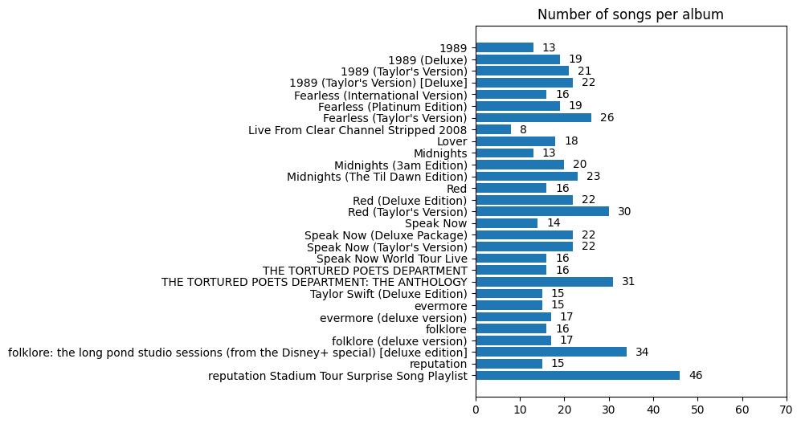

```python
# Get the albums, dropping nans
albums = df['album'].dropna().values

album_counter = Counter(albums)
n_albums = len(album_counter)

# get a sorted list of albums, in reverse alphabetical order
list_of_albums = sorted(album_counter)[::-1]

# get the count for each album
album_counts = [album_counter[g] for g in list_of_albums]

# Make a bar plot of albums counts
fig, ax = plt.subplots(figsize=(5, 6))

ax.barh(range(n_albums), album_counts)

ax.set_yticks(range(n_albums))
ax.set_yticklabels(list_of_albums)

# add text labels for the counts  (with some minor tweaks)
for i, g in enumerate(list_of_albums):
    ax.text(album_counter[g]+2, i-.3, str(album_counter[g]), size=10)

# fix the plot limits
ax.set_xlim(0, 70)

ax.set_title('Number of songs per album')

plt.show()
```

### Exercise 6: Modify the above plot to put the number labels inside the bar, in white text, for albums with more than 20 songs.

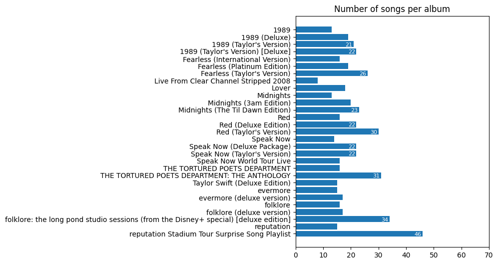

```python
# insert code here
# Get the albums, dropping nans
albums = df['album'].dropna().values

album_counter = Counter(albums)
n_albums = len(album_counter)

# get a sorted list of albums, in reverse alphabetical order
list_of_albums = sorted(album_counter)[::-1]

# get the count for each album
album_counts = [album_counter[g] for g in list_of_albums]

# Make a bar plot of albums counts
fig, ax = plt.subplots(figsize=(5, 6))

ax.barh(range(n_albums), album_counts)

ax.set_yticks(range(n_albums))
ax.set_yticklabels(list_of_albums)

# add text labels for the counts  (with some minor tweaks)
for i, g in enumerate(list_of_albums):
    if album_counter[g] > 20:
        ax.text(album_counter[g]-3, i-.3, str(album_counter[g]), size=8, color='white')

# fix the plot limits
ax.set_xlim(0, 70)

ax.set_title('Number of songs per album')

plt.show()
```

### Exercise 7: Export this notebook as an html file.

Click the "..." next to Outline at the top of VS code. Then click export and select html.

## Bonus Content: XKCD Plot

Matplotlib has some built in styles, like [XKCD](https://xkcd.com/)'s signature style. For more information: [read the documentation](https://matplotlib.org/stable/gallery/showcase/xkcd.html#sphx-glr-gallery-showcase-xkcd-py).

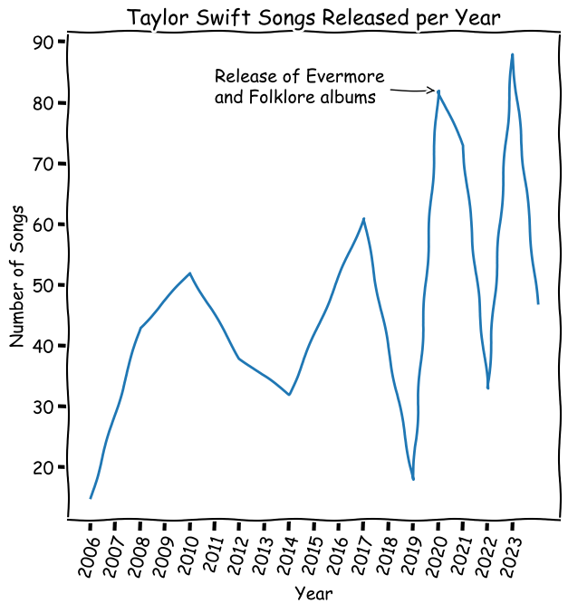

```python
# disable warning messages for fonts not found
import logging
logging.getLogger('matplotlib.font_manager').disabled = True

# get the year from the data
df['year']=pd.to_datetime(df['release_date'],format='%Y-%m-%d').dt.year
# group by the year
songs_by_date = df.groupby('year')['name'].count().reset_index()

# plot in XKCD style
with plt.xkcd():
    fig, ax = plt.subplots(figsize=(7, 7))
    ax.plot(songs_by_date['year'],songs_by_date['name'])
    ax.set_ylabel('Number of Songs')
    ax.set_xlabel('Year')
    ax.set_title('Taylor Swift Songs Released per Year')

    # set x ticks specifically & rotate
    ax.set_xticks([x for x in range(min(songs_by_date['year'].values),max(songs_by_date['year'].values))])
    ax.set_xticklabels(ax.get_xticklabels(), rotation=75)

    # add an annotation with an arrow
    ax.annotate(
        'Release of Evermore\nand Folklore albums',
        xy=(2020, 82), arrowprops=dict(arrowstyle='->'), xytext=(2011, 80))

plt.show()
```

### Bonus Exercise: Can you recreate the below chart?

Here's some data manipulation to start:

```
# group by the year to get popularity
pop_by_year = df.groupby('year')['popularity'].mean().reset_index()
```

[figure not shown]

```python
# insert code here
```